# Chapter 3: Data transformation with dplyr

## Filter

### Exercise 1-a

Flights with arrival delay of 2hrs or more.

```r
flights %>% select(flight, arr_delay) %>%
  filter(arr_delay >= 120) %>%
  arrange(desc(flight))
# 10200
```

### Exercise 1-b

Flights to Houston (IAH or HOU)

```r
# glimpse(flights)

flights %>% select(flight, dest) %>%
  filter(dest %in% c("IAH", "HOU")) %>%
  arrange(desc(flight))
# 9313
```

### Exercise 1-c

Flights operated by United, American or Delta

```r
# Which flight operators are present?
flights %>% distinct(carrier) %>% arrange(desc(carrier))

# Filter UA, AA, DL
flights %>% filter(carrier %in% c("UA", "AA", "DL"))
# 139504 flights
```

### Exercise 1-d

Flights departed in summer (July, August, September)

```r
flights %>% filter(month %in% c(7, 8, 9))
# 86326 flights

# alternative methods
# flights %>% filter(month >= 7 & month <= 9)
# flights %>% filter(between(month, 7, 9))
```

### Exercise 1-e

Arrived more than 2 hours later but didn’t leave late.

```r
flights %>% filter(arr_delay > 120 & dep_delay == 0)
# 3 flights
```

### Exercise 1-f

Delayed by at least an hour but made up at least 30 minutes in flight.

| year | month | day | dep_time | sched_dep_time | dep_delay | arr_time | sched_arr_time | arr_delay | carrier | flight | tailnum | origin | dest | air_time | distance | hour | minute | time_hour |
| --- | --- | --- | --- | --- | --- | --- | --- | --- | --- | --- | --- | --- | --- | --- | --- | --- | --- | --- |

### Exercise 1-g

Departed between midnight and 6am, inclusive.

```r
# Visualise flight distribution
# ggplot(flights, aes(x = dep_time)) +
#  geom_histogram(binwidth = 60)

flights %>% filter(dep_time >= 0 & dep_time <= 600)
# 9344 flights
```

### Exercise 2

See 1-d above

### Exercise 3

How many flights have missing `dep_time`?

| year | month | day | dep_time | sched_dep_time | dep_delay | arr_time | sched_arr_time | arr_delay | carrier | flight | tailnum | origin | dest | air_time | distance | hour | minute | time_hour |
| --- | --- | --- | --- | --- | --- | --- | --- | --- | --- | --- | --- | --- | --- | --- | --- | --- | --- | --- |
| 2013 | 1 | 1 | NA | 1630 | NA | NA | 1815 | NA | EV | 4308 | N18120 | EWR | RDU | NA | 416 | 16 | 30 | 2013-01-01 16:00:00 |
| 2013 | 1 | 1 | NA | 1935 | NA | NA | 2240 | NA | AA | 791 | N3EHAA | LGA | DFW | NA | 1389 | 19 | 35 | 2013-01-01 19:00:00 |
| 2013 | 1 | 1 | NA | 1500 | NA | NA | 1825 | NA | AA | 1925 | N3EVAA | LGA | MIA | NA | 1096 | 15 | 0 | 2013-01-01 15:00:00 |
| 2013 | 1 | 1 | NA | 600 | NA | NA | 901 | NA | B6 | 125 | N618JB | JFK | FLL | NA | 1069 | 6 | 0 | 2013-01-01 06:00:00 |
| 2013 | 1 | 2 | NA | 1540 | NA | NA | 1747 | NA | EV | 4352 | N10575 | EWR | CVG | NA | 569 | 15 | 40 | 2013-01-02 15:00:00 |
| 2013 | 1 | 2 | NA | 1620 | NA | NA | 1746 | NA | EV | 4406 | N13949 | EWR | PIT | NA | 319 | 16 | 20 | 2013-01-02 16:00:00 |
| 2013 | 1 | 2 | NA | 1355 | NA | NA | 1459 | NA | EV | 4434 | N10575 | EWR | MHT | NA | 209 | 13 | 55 | 2013-01-02 13:00:00 |
| 2013 | 1 | 2 | NA | 1420 | NA | NA | 1644 | NA | EV | 4935 | N759EV | EWR | ATL | NA | 746 | 14 | 20 | 2013-01-02 14:00:00 |
| 2013 | 1 | 2 | NA | 1321 | NA | NA | 1536 | NA | EV | 3849 | N13550 | EWR | IND | NA | 645 | 13 | 21 | 2013-01-02 13:00:00 |
| 2013 | 1 | 2 | NA | 1545 | NA | NA | 1910 | NA | AA | 133 | NA | JFK | LAX | NA | 2475 | 15 | 45 | 2013-01-02 15:00:00 |

[output cut: 990 more lines]

### Exercise 4

```r
NA ^ 0
# 1

NA | TRUE
# TRUE

FALSE & NA
# FALSE

NA * 0
# NA
```

## Arrange

### Exercise 1

Sort NAs to start.

| year | month | day | dep_time | sched_dep_time | dep_delay | arr_time | sched_arr_time | arr_delay | carrier | flight | tailnum | origin | dest | air_time | distance | hour | minute | time_hour |
| --- | --- | --- | --- | --- | --- | --- | --- | --- | --- | --- | --- | --- | --- | --- | --- | --- | --- | --- |
| 2013 | 1 | 1 | NA | 1630 | NA | NA | 1815 | NA | EV | 4308 | N18120 | EWR | RDU | NA | 416 | 16 | 30 | 2013-01-01 16:00:00 |
| 2013 | 1 | 1 | NA | 1935 | NA | NA | 2240 | NA | AA | 791 | N3EHAA | LGA | DFW | NA | 1389 | 19 | 35 | 2013-01-01 19:00:00 |
| 2013 | 1 | 1 | NA | 1500 | NA | NA | 1825 | NA | AA | 1925 | N3EVAA | LGA | MIA | NA | 1096 | 15 | 0 | 2013-01-01 15:00:00 |
| 2013 | 1 | 1 | NA | 600 | NA | NA | 901 | NA | B6 | 125 | N618JB | JFK | FLL | NA | 1069 | 6 | 0 | 2013-01-01 06:00:00 |
| 2013 | 1 | 2 | NA | 1540 | NA | NA | 1747 | NA | EV | 4352 | N10575 | EWR | CVG | NA | 569 | 15 | 40 | 2013-01-02 15:00:00 |
| 2013 | 1 | 2 | NA | 1620 | NA | NA | 1746 | NA | EV | 4406 | N13949 | EWR | PIT | NA | 319 | 16 | 20 | 2013-01-02 16:00:00 |
| 2013 | 1 | 2 | NA | 1355 | NA | NA | 1459 | NA | EV | 4434 | N10575 | EWR | MHT | NA | 209 | 13 | 55 | 2013-01-02 13:00:00 |
| 2013 | 1 | 2 | NA | 1420 | NA | NA | 1644 | NA | EV | 4935 | N759EV | EWR | ATL | NA | 746 | 14 | 20 | 2013-01-02 14:00:00 |
| 2013 | 1 | 2 | NA | 1321 | NA | NA | 1536 | NA | EV | 3849 | N13550 | EWR | IND | NA | 645 | 13 | 21 | 2013-01-02 13:00:00 |
| 2013 | 1 | 2 | NA | 1545 | NA | NA | 1910 | NA | AA | 133 | NA | JFK | LAX | NA | 2475 | 15 | 45 | 2013-01-02 15:00:00 |

[output cut: 990 more lines]

### Exercise 2

Most delayed flights.

| year | month | day | dep_time | sched_dep_time | dep_delay | arr_time | sched_arr_time | arr_delay | carrier | flight | tailnum | origin | dest | air_time | distance | hour | minute | time_hour |
| --- | --- | --- | --- | --- | --- | --- | --- | --- | --- | --- | --- | --- | --- | --- | --- | --- | --- | --- |
| 2013 | 1 | 9 | 641 | 900 | 1301 | 1242 | 1530 | 1272 | HA | 51 | N384HA | JFK | HNL | 640 | 4983 | 9 | 0 | 2013-01-09 09:00:00 |
| 2013 | 6 | 15 | 1432 | 1935 | 1137 | 1607 | 2120 | 1127 | MQ | 3535 | N504MQ | JFK | CMH | 74 | 483 | 19 | 35 | 2013-06-15 19:00:00 |
| 2013 | 1 | 10 | 1121 | 1635 | 1126 | 1239 | 1810 | 1109 | MQ | 3695 | N517MQ | EWR | ORD | 111 | 719 | 16 | 35 | 2013-01-10 16:00:00 |
| 2013 | 9 | 20 | 1139 | 1845 | 1014 | 1457 | 2210 | 1007 | AA | 177 | N338AA | JFK | SFO | 354 | 2586 | 18 | 45 | 2013-09-20 18:00:00 |
| 2013 | 7 | 22 | 845 | 1600 | 1005 | 1044 | 1815 | 989 | MQ | 3075 | N665MQ | JFK | CVG | 96 | 589 | 16 | 0 | 2013-07-22 16:00:00 |
| 2013 | 4 | 10 | 1100 | 1900 | 960 | 1342 | 2211 | 931 | DL | 2391 | N959DL | JFK | TPA | 139 | 1005 | 19 | 0 | 2013-04-10 19:00:00 |
| 2013 | 3 | 17 | 2321 | 810 | 911 | 135 | 1020 | 915 | DL | 2119 | N927DA | LGA | MSP | 167 | 1020 | 8 | 10 | 2013-03-17 08:00:00 |
| 2013 | 6 | 27 | 959 | 1900 | 899 | 1236 | 2226 | 850 | DL | 2007 | N3762Y | JFK | PDX | 313 | 2454 | 19 | 0 | 2013-06-27 19:00:00 |
| 2013 | 7 | 22 | 2257 | 759 | 898 | 121 | 1026 | 895 | DL | 2047 | N6716C | LGA | ATL | 109 | 762 | 7 | 59 | 2013-07-22 07:00:00 |
| 2013 | 12 | 5 | 756 | 1700 | 896 | 1058 | 2020 | 878 | AA | 172 | N5DMAA | EWR | MIA | 149 | 1085 | 17 | 0 | 2013-12-05 17:00:00 |

[output cut: 990 more lines]

Flights that left earliest.

| year | month | day | dep_time | sched_dep_time | dep_delay | arr_time | sched_arr_time | arr_delay | carrier | flight | tailnum | origin | dest | air_time | distance | hour | minute | time_hour |
| --- | --- | --- | --- | --- | --- | --- | --- | --- | --- | --- | --- | --- | --- | --- | --- | --- | --- | --- |
| 2013 | 12 | 7 | 2040 | 2123 | -43 | 40 | 2352 | 48 | B6 | 97 | N592JB | JFK | DEN | 265 | 1626 | 21 | 23 | 2013-12-07 21:00:00 |
| 2013 | 2 | 3 | 2022 | 2055 | -33 | 2240 | 2338 | -58 | DL | 1715 | N612DL | LGA | MSY | 162 | 1183 | 20 | 55 | 2013-02-03 20:00:00 |
| 2013 | 11 | 10 | 1408 | 1440 | -32 | 1549 | 1559 | -10 | EV | 5713 | N825AS | LGA | IAD | 52 | 229 | 14 | 40 | 2013-11-10 14:00:00 |
| 2013 | 1 | 11 | 1900 | 1930 | -30 | 2233 | 2243 | -10 | DL | 1435 | N934DL | LGA | TPA | 139 | 1010 | 19 | 30 | 2013-01-11 19:00:00 |
| 2013 | 1 | 29 | 1703 | 1730 | -27 | 1947 | 1957 | -10 | F9 | 837 | N208FR | LGA | DEN | 250 | 1620 | 17 | 30 | 2013-01-29 17:00:00 |
| 2013 | 8 | 9 | 729 | 755 | -26 | 1002 | 955 | 7 | MQ | 3478 | N711MQ | LGA | DTW | 88 | 502 | 7 | 55 | 2013-08-09 07:00:00 |
| 2013 | 10 | 23 | 1907 | 1932 | -25 | 2143 | 2143 | 0 | EV | 4361 | N13994 | EWR | TYS | 111 | 631 | 19 | 32 | 2013-10-23 19:00:00 |
| 2013 | 3 | 30 | 2030 | 2055 | -25 | 2213 | 2250 | -37 | MQ | 4573 | N725MQ | LGA | DTW | 87 | 502 | 20 | 55 | 2013-03-30 20:00:00 |
| 2013 | 3 | 2 | 1431 | 1455 | -24 | 1601 | 1631 | -30 | 9E | 3318 | N929XJ | JFK | BUF | 55 | 301 | 14 | 55 | 2013-03-02 14:00:00 |
| 2013 | 5 | 5 | 934 | 958 | -24 | 1225 | 1309 | -44 | B6 | 375 | N531JB | LGA | FLL | 150 | 1076 | 9 | 58 | 2013-05-05 09:00:00 |

[output cut: 990 more lines]

### Exercise 3

Sort to find fastest flights.

| year | month | day | dep_time | sched_dep_time | dep_delay | arr_time | sched_arr_time | arr_delay | carrier | flight | tailnum | origin | dest | air_time | distance | hour | minute | time_hour |
| --- | --- | --- | --- | --- | --- | --- | --- | --- | --- | --- | --- | --- | --- | --- | --- | --- | --- | --- |
| 2013 | 5 | 25 | 1709 | 1700 | 9 | 1923 | 1937 | -14 | DL | 1499 | N666DN | LGA | ATL | 65 | 762 | 17 | 0 | 2013-05-25 17:00:00 |
| 2013 | 7 | 2 | 1558 | 1513 | 45 | 1745 | 1719 | 26 | EV | 4667 | N17196 | EWR | MSP | 93 | 1008 | 15 | 13 | 2013-07-02 15:00:00 |
| 2013 | 5 | 13 | 2040 | 2025 | 15 | 2225 | 2226 | -1 | EV | 4292 | N14568 | EWR | GSP | 55 | 594 | 20 | 25 | 2013-05-13 20:00:00 |
| 2013 | 3 | 23 | 1914 | 1910 | 4 | 2045 | 2043 | 2 | EV | 3805 | N12567 | EWR | BNA | 70 | 748 | 19 | 10 | 2013-03-23 19:00:00 |
| 2013 | 1 | 12 | 1559 | 1600 | -1 | 1849 | 1917 | -28 | DL | 1902 | N956DL | LGA | PBI | 105 | 1035 | 16 | 0 | 2013-01-12 16:00:00 |
| 2013 | 11 | 17 | 650 | 655 | -5 | 1059 | 1150 | -51 | DL | 315 | N3768 | JFK | SJU | 170 | 1598 | 6 | 55 | 2013-11-17 06:00:00 |
| 2013 | 2 | 21 | 2355 | 2358 | -3 | 412 | 438 | -26 | B6 | 707 | N779JB | JFK | SJU | 172 | 1598 | 23 | 58 | 2013-02-21 23:00:00 |
| 2013 | 11 | 17 | 759 | 800 | -1 | 1212 | 1255 | -43 | AA | 936 | N5FFAA | JFK | STT | 175 | 1623 | 8 | 0 | 2013-11-17 08:00:00 |
| 2013 | 11 | 16 | 2003 | 1925 | 38 | 17 | 36 | -19 | DL | 347 | N3773D | JFK | SJU | 173 | 1598 | 19 | 25 | 2013-11-16 19:00:00 |
| 2013 | 11 | 16 | 2349 | 2359 | -10 | 402 | 440 | -38 | B6 | 1503 | N571JB | JFK | SJU | 173 | 1598 | 23 | 59 | 2013-11-16 23:00:00 |

[output cut: 990 more lines]

### Exercise 4

Longest travelled flights.

```r
flights %>% arrange(desc(distance))
# JFK to HNL the longest
```

Shortest travelled flights.

| year | month | day | dep_time | sched_dep_time | dep_delay | arr_time | sched_arr_time | arr_delay | carrier | flight | tailnum | origin | dest | air_time | distance | hour | minute | time_hour |
| --- | --- | --- | --- | --- | --- | --- | --- | --- | --- | --- | --- | --- | --- | --- | --- | --- | --- | --- |
| 2013 | 7 | 27 | NA | 106 | NA | NA | 245 | NA | US | 1632 | NA | EWR | LGA | NA | 17 | 1 | 6 | 2013-07-27 01:00:00 |
| 2013 | 1 | 3 | 2127 | 2129 | -2 | 2222 | 2224 | -2 | EV | 3833 | N13989 | EWR | PHL | 30 | 80 | 21 | 29 | 2013-01-03 21:00:00 |
| 2013 | 1 | 4 | 1240 | 1200 | 40 | 1333 | 1306 | 27 | EV | 4193 | N14972 | EWR | PHL | 30 | 80 | 12 | 0 | 2013-01-04 12:00:00 |
| 2013 | 1 | 4 | 1829 | 1615 | 134 | 1937 | 1721 | 136 | EV | 4502 | N15983 | EWR | PHL | 28 | 80 | 16 | 15 | 2013-01-04 16:00:00 |
| 2013 | 1 | 4 | 2128 | 2129 | -1 | 2218 | 2224 | -6 | EV | 4645 | N27962 | EWR | PHL | 32 | 80 | 21 | 29 | 2013-01-04 21:00:00 |
| 2013 | 1 | 5 | 1155 | 1200 | -5 | 1241 | 1306 | -25 | EV | 4193 | N14902 | EWR | PHL | 29 | 80 | 12 | 0 | 2013-01-05 12:00:00 |
| 2013 | 1 | 6 | 2125 | 2129 | -4 | 2224 | 2224 | 0 | EV | 4619 | N22909 | EWR | PHL | 22 | 80 | 21 | 29 | 2013-01-06 21:00:00 |
| 2013 | 1 | 7 | 2124 | 2129 | -5 | 2212 | 2224 | -12 | EV | 4619 | N33182 | EWR | PHL | 25 | 80 | 21 | 29 | 2013-01-07 21:00:00 |
| 2013 | 1 | 8 | 2127 | 2130 | -3 | 2304 | 2225 | 39 | EV | 4619 | N11194 | EWR | PHL | 30 | 80 | 21 | 30 | 2013-01-08 21:00:00 |
| 2013 | 1 | 9 | 2126 | 2129 | -3 | 2217 | 2224 | -7 | EV | 4619 | N17560 | EWR | PHL | 27 | 80 | 21 | 29 | 2013-01-09 21:00:00 |

[output cut: 990 more lines]

## Select

### Exercise 1

Different select routes for dep_time, dep_delay, arr_time, and arr_delay from flights.

```r
# glimpse(flights)
library(microbenchmark)
dplyr1 <- flights %>% select(dep_time, dep_delay, arr_time, arr_delay)
dplyr1_2 <- select(flights, dep_time, dep_delay, arr_time, arr_delay)
dplyr2 <- flights %>% select(starts_with("dep_"),  starts_with("arr_"))
dplyr2_2 <- select(flights, starts_with("dep_"),  starts_with("arr_"))
# Base R
vars <- c("dep_time", "dep_delay", "arr_time", "arr_delay")
base1 <- flights[vars]
# Time
bench <- microbenchmark(dplyr1, dplyr1_2, dplyr2, dplyr2_2, base1, times = 10000L)
bench
```

```
Unit: nanoseconds
     expr min lq     mean median uq   max neval
   dplyr1  40 58 100.1260     69 75 29439 10000
 dplyr1_2  40 59 110.6987     68 75 49476 10000
   dplyr2  44 59 113.2227     72 76 48995 10000
 dplyr2_2  40 56 116.0120     68 72 33502 10000
    base1  38 58 120.2108     70 75 53556 10000
```

```r
rm(list = ls())
```

### Exercise 2

Include variable multiple times

```r
flights %>% select(dep_delay, dep_delay)
```

Only return one column.

### Exercise 3

`one_of()` selects from a character vector. This vector could be passed directly to `select`.

| year | month | day | dep_delay | arr_delay |
| --- | --- | --- | --- | --- |
| 2013 | 1 | 1 | 2 | 11 |
| 2013 | 1 | 1 | 4 | 20 |
| 2013 | 1 | 1 | 2 | 33 |
| 2013 | 1 | 1 | -1 | -18 |
| 2013 | 1 | 1 | -6 | -25 |
| 2013 | 1 | 1 | -4 | 12 |
| 2013 | 1 | 1 | -5 | 19 |
| 2013 | 1 | 1 | -3 | -14 |
| 2013 | 1 | 1 | -3 | -8 |
| 2013 | 1 | 1 | -2 | 8 |

[output cut: 990 more lines]

### Exercise 4

The following is not case sensitive.

| dep_time | sched_dep_time | arr_time | sched_arr_time | air_time | time_hour |
| --- | --- | --- | --- | --- | --- |
| 517 | 515 | 830 | 819 | 227 | 2013-01-01 05:00:00 |
| 533 | 529 | 850 | 830 | 227 | 2013-01-01 05:00:00 |
| 542 | 540 | 923 | 850 | 160 | 2013-01-01 05:00:00 |
| 544 | 545 | 1004 | 1022 | 183 | 2013-01-01 05:00:00 |
| 554 | 600 | 812 | 837 | 116 | 2013-01-01 06:00:00 |
| 554 | 558 | 740 | 728 | 150 | 2013-01-01 05:00:00 |
| 555 | 600 | 913 | 854 | 158 | 2013-01-01 06:00:00 |
| 557 | 600 | 709 | 723 | 53 | 2013-01-01 06:00:00 |
| 557 | 600 | 838 | 846 | 140 | 2013-01-01 06:00:00 |
| 558 | 600 | 753 | 745 | 138 | 2013-01-01 06:00:00 |

[output cut: 990 more lines]

The select helper `contains` can be ammended to be case sensitive.

```r
select(flights, contains("TIME", ignore.case = FALSE))
```

But there are no columns with TIME in their name.

## Mutate and transmute

### Exercise 1

Convert `dep_time` and `sched_dep_time` (presented as hhmm) into total number of minutes.

| dep_time_mins | sched_dep_time_mins |
| --- | --- |
| 317 | 315 |
| 333 | 329 |
| 342 | 340 |
| 344 | 345 |
| 354 | 360 |
| 354 | 358 |
| 355 | 360 |
| 357 | 360 |
| 357 | 360 |
| 358 | 360 |

[output cut: 990 more lines]

### Exercise 2

Compare `air_time` with `arr_time`-`dep_time`.

They should be the same. Let’s check…

| air_time | arr_dep_time |
| --- | --- |
| 227 | 313 |
| 227 | 317 |
| 160 | 381 |
| 183 | 460 |
| 116 | 258 |
| 150 | 186 |
| 158 | 358 |
| 53 | 152 |
| 140 | 281 |
| 138 | 195 |

[output cut: 990 more lines]

They are not the same.

Why?

Arrival and depart times are in hhmm format so we can convert these into pure minutes.

| carrier | flight | air_time | arr_dep_mins | air_time_diff |
| --- | --- | --- | --- | --- |
| B6 | 215 | 200 | 404 | 204 |
| AA | 413 | 200 | 394 | 194 |
| DL | 2131 | 72 | 257 | 185 |
| UA | 1542 | 70 | 254 | 184 |
| B6 | 725 | 189 | 371 | 182 |
| AA | 1769 | 147 | 323 | 176 |
| B6 | 2302 | 57 | 231 | 174 |
| DL | 2395 | 163 | 333 | 170 |
| MQ | 3526 | 69 | 238 | 169 |
| MQ | 2793 | 96 | 265 | 169 |

[output cut: 990 more lines]

There is still a difference. Are there any instances where two methods are the same?

| origin | dest | air_time | arr_time | dep_time | arr_dep_mins | air_time_diff |
| --- | --- | --- | --- | --- | --- | --- |
| EWR | IAH | 227 | 830 | 517 | 193 | -34 |
| LGA | IAH | 227 | 850 | 533 | 197 | -30 |
| JFK | MIA | 160 | 923 | 542 | 221 | 61 |
| JFK | BQN | 183 | 1004 | 544 | 260 | 77 |
| LGA | ATL | 116 | 812 | 554 | 138 | 22 |
| EWR | ORD | 150 | 740 | 554 | 106 | -44 |
| EWR | FLL | 158 | 913 | 555 | 198 | 40 |
| LGA | IAD | 53 | 709 | 557 | 72 | 19 |
| JFK | MCO | 140 | 838 | 557 | 161 | 21 |
| LGA | ORD | 138 | 753 | 558 | 115 | -23 |

[output cut: 990 more lines]

```r
flights %>% transmute(carrier, flight, origin, dest, air_time,
                      arr_time, dep_time,
                      arr_dep_mins = hhmm2mins(arr_time) - hhmm2mins(dep_time)) %>%
  mutate(air_time_diff = arr_dep_mins - air_time) %>%
  select(-carrier, -flight)

# %>% filter(air_time == arr_dep_mins)
```

### Exercise 3

Comparing `dep_time`, `sched_dep_time` and `dep_delay`. `dep_delay` should be `dep_time` - `sched_dep_time`.

| flight | origin | dest | dep_time | sched_dep_time | dep_delay | dep_delay_calc |
| --- | --- | --- | --- | --- | --- | --- |
| 1503 | JFK | SJU | 1 | 2359 | 2 | -1438 |
| 839 | JFK | BQN | 1 | 2359 | 2 | -1438 |
| 1503 | JFK | SJU | 1 | 2359 | 2 | -1438 |
| 1503 | JFK | SJU | 1 | 2359 | 2 | -1438 |
| 839 | JFK | BQN | 1 | 2359 | 2 | -1438 |
| 727 | JFK | BQN | 1 | 2359 | 2 | -1438 |
| 727 | JFK | BQN | 1 | 2359 | 2 | -1438 |
| 745 | JFK | PSE | 1 | 2359 | 2 | -1438 |
| 839 | JFK | BQN | 1 | 2359 | 2 | -1438 |
| 745 | JFK | PSE | 1 | 2359 | 2 | -1438 |

[output cut: 990 more lines]

However, overnight flights create a problem with performing simple subtraction of `dep_time` - `sched_dep_time` to obtain flight delays for all journeys.

### Exercise 4

Find the 10 most delayed flights using ranking.

Visualise.

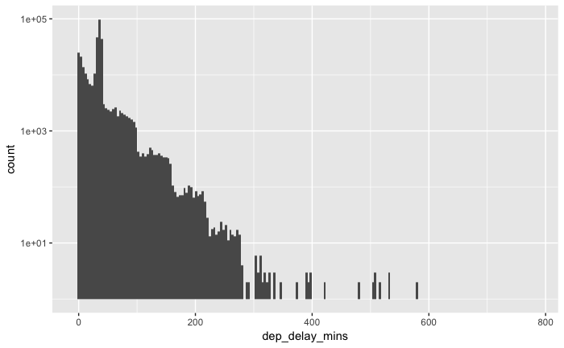

`min_rank` assigns ties to same rank number and skips rank numbers below ties eg rank: …21, 22, 22, 24,…

| flight | carrier | dep_delay | arr_delay | rank |
| --- | --- | --- | --- | --- |
| 51 | HA | 1301 | 1272 | 1 |
| 3535 | MQ | 1137 | 1127 | 2 |
| 3695 | MQ | 1126 | 1109 | 3 |
| 177 | AA | 1014 | 1007 | 4 |
| 3075 | MQ | 1005 | 989 | 5 |
| 2391 | DL | 960 | 931 | 6 |
| 2119 | DL | 911 | 915 | 7 |
| 2047 | DL | 898 | 895 | 8 |
| 172 | AA | 896 | 878 | 9 |
| 3744 | MQ | 878 | 875 | 10 |

[output cut: 990 more lines]

`dense_rank` assigns ties to same rank number and doesn’t skip rank numbers eg rank: …21,22,22,23,…

| flight | carrier | dep_delay | arr_delay | rank |
| --- | --- | --- | --- | --- |
| 51 | HA | 1301 | 1272 | 1 |
| 3535 | MQ | 1137 | 1127 | 2 |
| 3695 | MQ | 1126 | 1109 | 3 |
| 177 | AA | 1014 | 1007 | 4 |
| 3075 | MQ | 1005 | 989 | 5 |
| 2391 | DL | 960 | 931 | 6 |
| 2119 | DL | 911 | 915 | 7 |
| 2047 | DL | 898 | 895 | 8 |
| 172 | AA | 896 | 878 | 9 |
| 3744 | MQ | 878 | 875 | 10 |

[output cut: 990 more lines]

`row_number` assigns ties to different rank numbers. How the tie is broken though? `rank()` man page not helpful.

| flight | carrier | dep_delay | arr_delay | rank |
| --- | --- | --- | --- | --- |
| 51 | HA | 1301 | 1272 | 1 |
| 3535 | MQ | 1137 | 1127 | 2 |
| 3695 | MQ | 1126 | 1109 | 3 |
| 177 | AA | 1014 | 1007 | 4 |
| 3075 | MQ | 1005 | 989 | 5 |
| 2391 | DL | 960 | 931 | 6 |
| 2119 | DL | 911 | 915 | 7 |
| 2047 | DL | 898 | 895 | 8 |
| 172 | AA | 896 | 878 | 9 |
| 3744 | MQ | 878 | 875 | 10 |

[output cut: 990 more lines]

### Exercise 5

Recycling of vector.

```r
1:3 + 1:10
```

```
longer object length is not a multiple of shorter object length
```

```
 [1]  2  4  6  5  7  9  8 10 12 11
```

### Exercise 6

Trigonometric functions. See `base::Trig`